# Final Project

Yingshan Li(7937790)

## Introduction

The purpose of this project is to generate a model that will predict the winner of a League Of Legends game based on the players’ first ten minutes of in-game performance.

### Basic Information About League Of Legends

League of Legends, also called LoL, is developed and published by Riot Games in 2009. It has been a very popular game since first published.

League of Legends is a team-based strategy MOBA game where two teams, a blue team, and a red team, of five powerful champions(characters that have different abilities), face off to destroy the other’s base. There are 3 lanes, a jungle, and 5 different roles for each team’s players to choose from. Each player can choose from over 140 champions that are dedicated to different roles. In each game. Players kill enemies and minions, take jungle resources, and destroy towers as them battle their way to victory. All these actions and along with the time increase, players earn gold and experiences to level up and equip their champion, which makes their champion much stronger.

LoL is also the world’s largest E-sport as it has 12 sub leagues for different regions of the world such as LPL for China, LCK for Korea, and LEC for Europe. Professional teams in these leagues compete every year for getting and fighting into the League of Legends World Championship and the Mid-Season Invitational(MSI), which are the biggest worldwide LoL competitions each year.

### Why Choose to Build This Model?

I am a player of LoL, so I am interested in the topic related to players’ performance and prediction results. Moreover, there is a winner prediction section pop up in the professional LoL competition at certain times of the game. The model could potentially be developed to make the winner prediction at the early stage of the game.

### Loading Data and Packages

The original data for this project comes from the RIOT API. The data record the first 10 mins of game statistics for both teams from nearly 10,000 SOLO ranked games of high-level players, from Diamond to Master. It is very difficult to reach diamonds and even higher, all the players after level Diamonds have the roughly same level of skills, so their game skills will not significantly affect the result. Each observation in the data set comes from a unique game, identified by unique game IDs. I downloaded the data from Kaggle.

The full copy of the codebook is available in the data folder. The prefix `blue` or `red` indicates the team of that data. The following Glossary comes from the data download page on Kaggle are some important professional LoL terminologies included in the variable names to be aware of for the following report:

- Warding totem: An item that a player can put on the map to reveal the nearby area. Very useful for map/objectives control.
- Minions: NPC that belong to both teams. They give gold when killed by players.
- Jungle minions: NPC that belong to NO TEAM. They give gold and buffs when killed by players.
- Elite monsters: Monsters(Dragons and Heralds) with high hp/damage that give a massive bonus (gold/XP/stats) when killed by a team.
- Dragons: Elite monster which gives team bonus when killed. The 4th dragon killed by a team gives a massive stats bonus. The 5th dragon (Elder Dragon) offers a huge advantage to the team.
- Herald: Elite monster which gives stats bonus when killed by the player. It helps to push a lane and destroys structures.
- Towers: Structures you have to destroy to reach the enemy Nexus. They give gold.
- Level: Champion level. Start at 1. Max is 18. Increase as experiences(XP) increases.

```r
# load packages
library(dplyr)
library(magrittr)
library(tidyverse)
library(tidymodels)
library(ISLR)
library(discrim)
library(poissonreg)
library(corrr)
library(klaR)
tidymodels_prefer()
library(ggplot2)
library(corrplot)
library(ggthemes)
library(janitor)
library(glmnet)
library(parsnip)
library(rpart.plot)
library(randomForest)
library(xgboost)
library(ranger)
library(vip)
library(rpart)
library(hablar)
library(ggcorrplot)
library(gridExtra)
library(cowplot)
library(hrbrthemes)
library(scales)
library(kknn)
library(readr)
library(filesstrings)
```

```r
# read in data
rank_original<- read.csv("data/unprocessed/unprocessed_diamonds_rank_10mins.csv")
```

## Data Cleaning and Processing

The original data set is already tidy and very ready to use with no missing values.

- Check missing values:

```r
# check missing values
sum(is.na(rank_original))
```

```
## [1] 0
```

Cleaning and processing steps for data to be used in further data analysis:

- Clean names

```r
rank <- rank_original %>%
  clean_names()
```

- Create a new variable `winner` and remove the variable `blue_wins`

  The dataset originally recorded the game results by the variable `blue_wins` with level 0 indicate red wins and level 1 indicate blue wins. I will create a new categorical variable `winner` based on `blue_wins` with levels “red” and “blue” to indicate the winner of each game.
- Transform `winner` to factor. Causing an error when I try to build model in the draft and forget to transform it into factor.

```r
rank <- rank %>%
  # create winner
  mutate(winner = if_else(blue_wins == 0, "red", "blue")) %>%
  # remove column blue_wins
  select(-blue_wins)

# transform to factor
rank <- rank %>%
  mutate(winner = factor(winner))
```

- Calculate KDA for both teams and create variables `blue_kda` and `red_kda`  
  KDA = (kill + assists)/death. KDA measures the ratio of how many enemies they have killed versus the times they have died. This is the most widely used statistic in LoL to show a player’s performance. Here, we use team statistics to calculate the KDA for both teams. There might be some arguments that adding assists might inflate the KDA figure, but since the assists can illustrate whether or not all the team members are involved in the game, so we still want to use KDA. I will incorporate KDA in the model fitting process as it is not just a simple linear relationship between variables and is indeed an essential figure used to show performances in the professional LoL league.
- Round the `blue_kda` and `red_kda` to 2 decimal place

```r
rank <- rank %>%
  # calculate and create blue kda
  mutate(blue_kda= (blue_kills+blue_assists)/blue_deaths) %>%
  # calcuate and create red kda
  mutate(red_kda = (red_kills+red_assists)/red_deaths) %>%
  # round to 2 digits
  mutate(blue_kda = round(blue_kda,2)) %>%
  mutate(red_kda = round(red_kda,2))
```

- Rationalize the data, change the inf value to NA

  The formula of calculating the KDA cause a problem since there are some circumstances that one side has 0 death in the first ten mins of the game. This causes `blue_kda` and `red_kda` contain data that is an infinite number, which is not usable in further analysis. Interestingly, for most of the time, when one side get an inf KDA, the other team has 0 KDA, which means that one side has significantly better performance than the other side. LoL has a very complex evaluation process that calculates a player’s kda if there is no death. For simplicity and interpretability at the same time, we will use the mean kill+assists figure from the data that `death = 0` to approximate the KDA for each side in this situation. Such a figure can also reflect a player’s performance as it shows how many kills the player has involved.

```r
# rationalize inf values
rank <- rank %>%
  rationalize()
```

- Calculate approximate KDA if `death`== 0

```r
# calculate approximate blue kda
blue_approx_kda <-rank %>%
  filter(blue_deaths == 0) %>%
  select(blue_kills,blue_assists) %>%
  summarise(mean(blue_kills) + mean(blue_assists))

# round it to 2 digits
round(blue_approx_kda,2)
```

```
## # A tibble: 1 × 1
##   `mean(blue_kills) + mean(blue_assists)`
##                                     <dbl>
## 1                                    12.0
```

```r
# calculate approximate red kda
red_approx_kda <- rank %>%
  filter(red_deaths == 0) %>%
  select(red_kills,red_assists) %>%
  summarise(mean(red_kills) + mean(red_assists))

# round it to 2 digits
round(red_approx_kda,2)
```

```
## # A tibble: 1 × 1
##   `mean(red_kills) + mean(red_assists)`
##                                   <dbl>
## 1                                  12.6
```

- Fill in NA by approximate KDA

```r
# fill in blue kda
rank <- rank %>%
  dplyr::mutate(blue_kda = replace_na(blue_kda, 12.03))
# fill in red kda
rank <- rank %>%
  dplyr::mutate(red_kda = replace_na(red_kda,12.65))
```

- Calculate vision score and create variables `blue_vision_score` and `red_vision_score`

  Vision score synthesize the variables about warding totem. Since wards placed can light the map and provide important vision, LoL game calculates the vision score based on the ward placed, ward destroyed, ward duration and any other thing that trigger more vision. Since we only got limited record on the ward, and the ward has strictly positively relationship with the vision score, I decide to compute the vision score by adding the wards_placed and the wards_destroyed for each team, which shows the number of actions that each team has undertaken to occupy more map vision.

```r
# create blue vision socre
rank <- rank %>%
  mutate(blue_vision_score = blue_wards_placed + blue_wards_destroyed)

# create red vision score
rank <- rank %>%
  mutate(red_vision_score = red_wards_placed + red_wards_destroyed)
```

- Remove variable `wards_placed` and `wards_destroyed` for both team

```r
rank <- rank %>%
  # remove blue wards variables
  select(-blue_wards_destroyed) %>%
  select(-blue_wards_placed) %>%
  # remove red wards variables
  select(-red_wards_destroyed) %>%
  select(-red_wards_placed)
```

- Compute new variable `first_blood` based on `red_first_blood` and `blue_first_blood`

  `red_first_blood` and `blue_first_blood` originally use level 0 or 1 to indicate whether the particular team has taken the first blood. We will synthesize the information and create a new column `first_blood` to clearly indicate which team has taken the first blood.
- Remove columns `red_first_blood` and `blue_first_blood`
- Transform `first_blood` to factor

```r
rank <- rank %>%
  # add first_blood column
  mutate(first_blood = if_else(blue_first_blood == 0, "red", "blue"))

# remove column blue_first_blood and red_first_blood
rank <- rank %>%
  select(-blue_first_blood) %>%
  select(-red_first_blood)

# change it to  factor
rank <- rank %>%
  mutate(first_blood = factor(first_blood))

# save the processed data and move it to data folder
write_csv(rank, file = "processed_data.csv")
file.move("processed_data.csv","data/processed/processed_data.csv")
```

## Exploratory Data Analysis

The exploratory data analysis based on the entire data set, a total of 9879 observations.

### Distribution of Outcome Variable - winner

First to check whether or not the total of 9879 games recorded in our data set contains approximately the same number of games that the blue team wins or the red team wins.

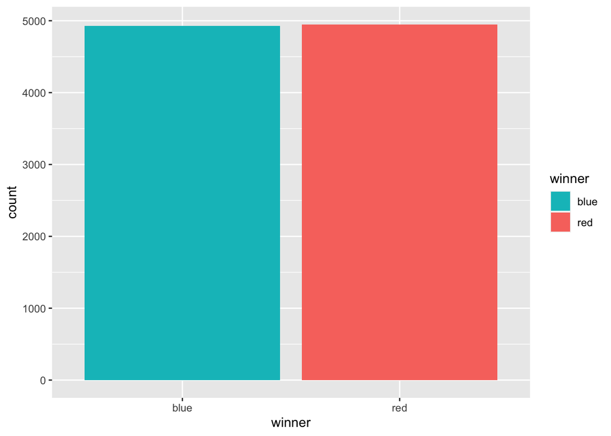

```r
rank %>%
  ggplot(aes(x = winner, fill = winner)) +
  geom_bar() +
  scale_fill_manual(values =  c("#00BFC4", "#F8766D") )
```

From the graph, we can observe that the number of games that the blue team wins is about the same as the number of games that the red team wins, so the data is very balanced for our further investigation.

### Correlations

Let us examine the correlations among important quantitative features for the blue and the red team separately:

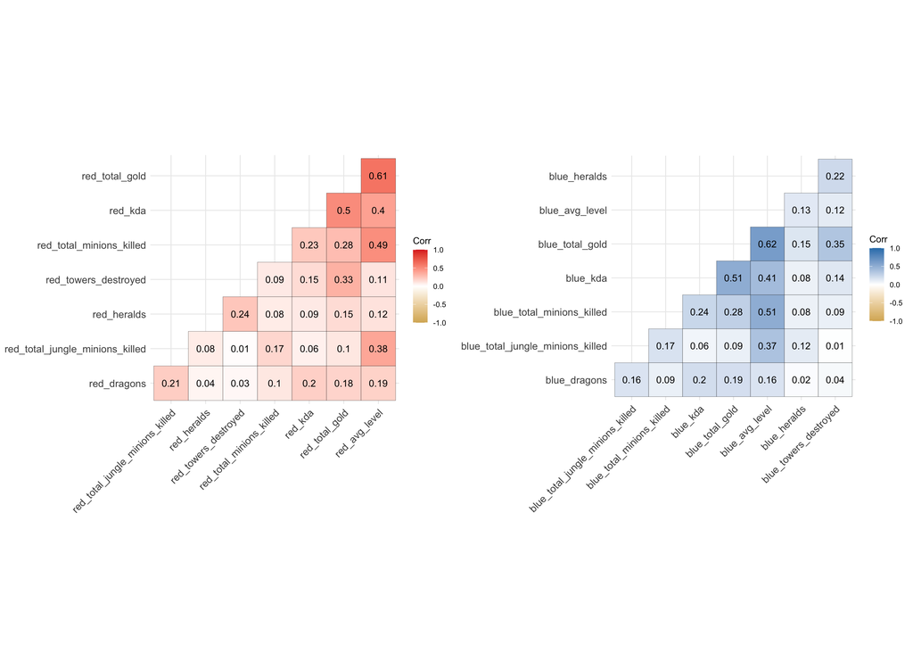

```r
rcor <- rank %>%
  select(red_kda,red_dragons,red_heralds,red_towers_destroyed,red_total_gold,red_avg_level,red_total_minions_killed,red_total_jungle_minions_killed) %>%
  cor()

red_corr <- ggcorrplot(rcor, hc.order = TRUE, type = "lower",
                       outline.color = "black",
                       colors = c("#d8b365","white", "#de2d26"), lab = TRUE)


bcor <- rank %>%
  select(blue_kda,blue_dragons,blue_heralds,blue_towers_destroyed,blue_total_gold,blue_avg_level,blue_total_minions_killed,blue_total_jungle_minions_killed) %>%
  cor()

blue_corr <- ggcorrplot(bcor, hc.order = TRUE, type = "lower",
                        outline.color = "black",
                        colors = c("#d8b365","white", "#2c7fb8"), lab = TRUE)


plot_grid(red_corr,blue_corr)
```

From the plot, there are no unexpected correlations among the variable. We can see that there are positive correlations between gold and all other performance statistics or average level and all other performance statistics such as KDA, minions_killed, or tower destroyed. This corresponds to game mechanics that as the performance of the player gets better, the player can get more bonuses for gold and experiences, which are important criteria to build up determinant advantages in the game.

### Gold&Exp vs Winner

I want to examine the distribution of gold and experiences by the winner. The plot uses the difference between gold and experiences between two teams. The differences are calculated using the blue figure minus the red figure.

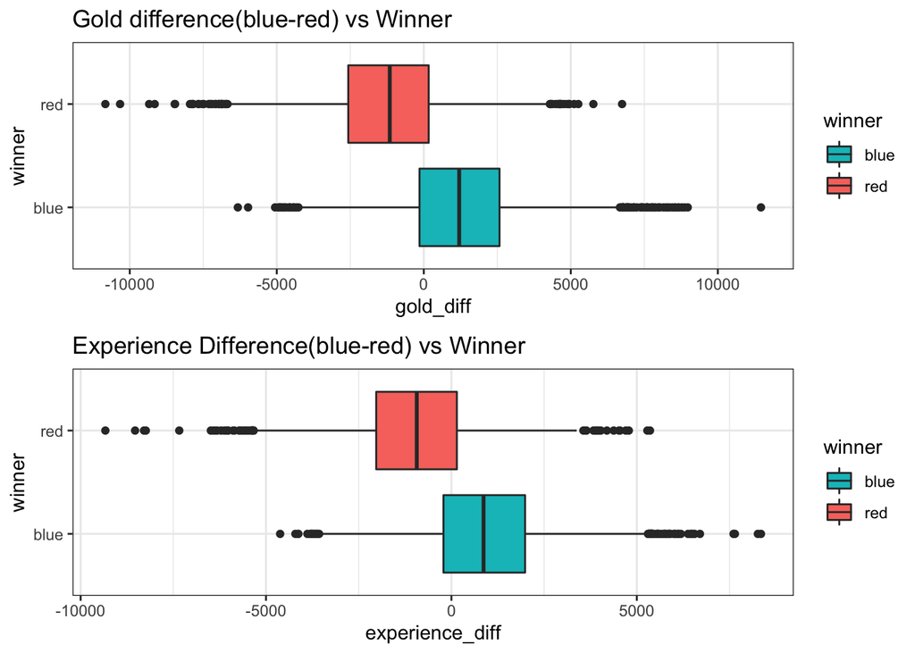

```r
gold_diff_plot <-rank %>%
  select(blue_gold_diff,winner) %>%
  ggplot(aes(x=blue_gold_diff, y = winner, fill=winner)) +
  geom_boxplot() +
  scale_fill_manual(values =  c("#00BFC4", "#F8766D")) +
  theme_bw()+
  ggtitle("Gold difference(blue-red) vs Winner") +
  labs(x="gold_diff", y = "winner")

experience_diff_plot<- rank %>%
  select(blue_experience_diff,winner) %>%
  ggplot(aes(x=blue_experience_diff, y = winner, fill=winner)) +
  geom_boxplot() +
  scale_fill_manual(values =  c("#00BFC4", "#F8766D")) +
  theme_bw()+
  ggtitle("Experience Difference(blue-red) vs Winner") +
  labs(x="experience_diff", y = "winner")

grid.arrange(gold_diff_plot,experience_diff_plot)
```

In general, we can see that the winning team has a lead in gold and experience than the other team at the early stage of the game. However, we can see that leading in the gold and experiences can not garantee you win the game.

### KDA vs Winner

Since killing the enemy champions is considered the most valuable performance in the world of LoL, KDA becomes the most important statistic in the League of Legends to choose MVP and evaluate each person’s performance. I hypothesize that KDA is one of the most determinant figure. Let’s see the distribution of KDA by the winner separately for two teams:

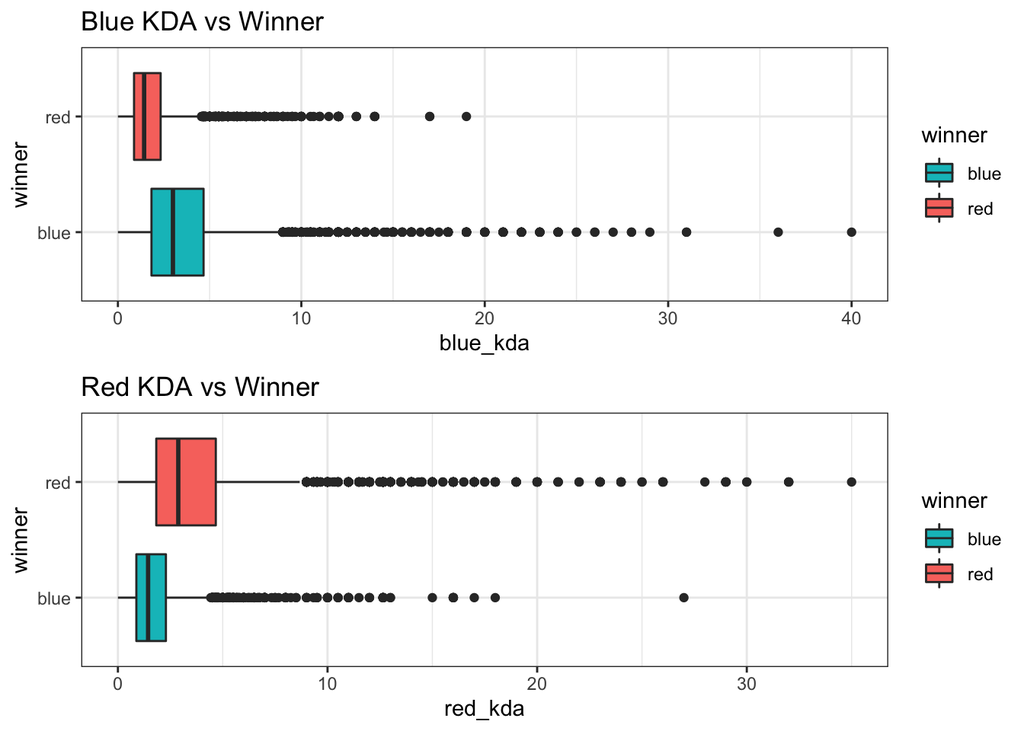

```r
blue_kda_plot<- rank %>%
  select(blue_kda,winner) %>%
  ggplot(aes(x=blue_kda, y = winner, fill=winner)) +
  geom_boxplot() +
  scale_fill_manual(values =  c("#00BFC4", "#F8766D")) +
  theme_bw()+
  ggtitle("Blue KDA vs Winner") +
  labs(x="blue_kda", y = "winner")

red_kda_plot <- rank %>%
  select(red_kda,winner) %>%
  ggplot(aes(x=red_kda, y = winner, fill=winner)) +
  geom_boxplot() +
  scale_fill_manual(values =  c("#00BFC4", "#F8766D")) +
  theme_bw()+
  ggtitle("Red KDA vs Winner") +
  labs(x="red_kda", y = "winner")

grid.arrange(blue_kda_plot,red_kda_plot)
```

We can see obviously that the team has a higher mean KDA in the first ten mins of the game when it wins the game. Still, the large potential variations and short time of game might cause such outliers in the plot.

### Public Jungle Resources vs Win Rate

Elite Monsters in LoL are public jungle resources that two sides compete for. Dragons and Heralds are elite monsters that will be born in the game for the first ten minutes, and there will be only one dragon and one herald in the first ten minutes of the game. Let’s first examine the win rate of taken elite monster and the win rate of taken both elite monsters, dragon and herald:

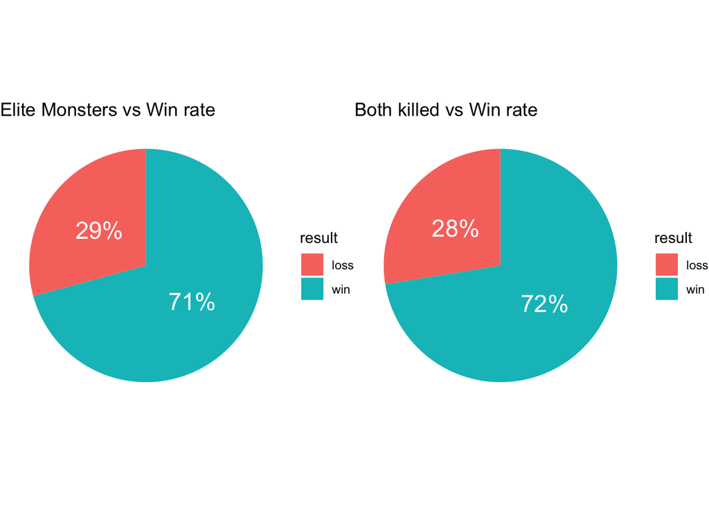

```r
EM_blue_win <-rank %>%
  filter(blue_elite_monsters >= 1 & winner == "blue")
EM_red_win <- rank %>%
  filter(red_elite_monsters >= 1 & winner == "red")
game_win_EM <- nrow(EM_blue_win) + nrow(EM_red_win)
EM_killed <- rank %>%
  filter(blue_elite_monsters >= 1 | red_elite_monsters >= 1)
game_loss_EM<-nrow(EM_killed)-game_win_EM
game_EM_killed <- nrow(EM_killed)

data_EM <- data.frame(
  result = c("win", "loss"),
  value = c(game_win_EM, game_loss_EM),
  perc = c(game_win_EM/game_EM_killed, game_loss_EM/game_EM_killed)
)

df_EM <- data_EM %>%
  mutate(labels = scales::percent(perc))

EM_plot <- ggplot(df_EM, aes(x="",y = perc, fill = result)) +
  geom_bar(stat = "identity", width = 1) +
  coord_polar("y", start = 0) +
  theme_void() +
  geom_text(aes(label = labels), position = position_stack(vjust = 0.5),color = "white",size = 6) +
  ggtitle("Elite Monsters vs Win rate")

both_blue_win <-rank %>%
  filter(blue_heralds >= 1 & blue_dragons >= 1 & winner == "blue")
both_red_win <- rank %>%
  filter(red_heralds >= 1 & red_dragons >= 1 & winner == "red")
game_win_both<- nrow(both_blue_win) + nrow(both_red_win)
blue_both_killed <- rank %>%
  filter(blue_heralds >= 1 & blue_dragons >= 1)
red_both_killed <- rank %>%
  filter(red_heralds >= 1 & red_dragons >= 1)
game_both_killed <- nrow(blue_both_killed) + nrow(red_both_killed)
game_loss_both<-game_both_killed- game_win_both

data_both <- data.frame(
  result = c("win", "loss"),
  value = c(game_win_both,game_loss_both),
  perc = c(game_win_both/game_both_killed, game_loss_both/game_both_killed)
)

df_both <- data_both %>%
  mutate(labels = scales::percent(perc))

both_plot <- ggplot(df_both, aes(x="",y = perc, fill = result)) +
  geom_bar(stat = "identity", width = 1) +
  coord_polar("y", start = 0) +
  theme_void() +
  geom_text(aes(label = labels), position = position_stack(vjust = 0.5),color = "white",size = 6) +
  ggtitle("Both killed vs Win rate")

plot_grid(EM_plot, both_plot)
```

From the plot, we can observe that getting both elite monsters in the early stage can not significantly increase the win rate. Approximately 71% of the team who has got at least one elite monster wins the game, which indicates that getting the elite monsters can increase the chance of winning the game.

Now, let’s examine the win rate for taken dragon and heralds separately:

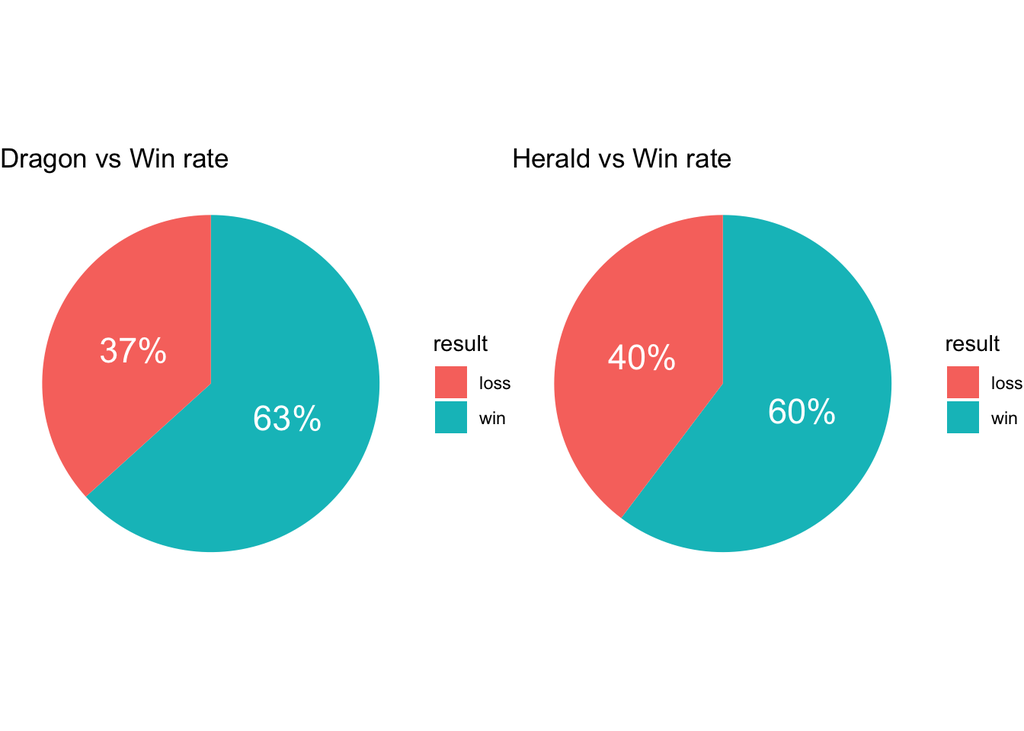

```r
dragons_blue_win <-rank %>%
  filter(blue_dragons >= 1 & winner == "blue")
dragons_red_win <- rank %>%
  filter(red_dragons >= 1 & winner == "red")
game_win_dragon <- nrow(dragons_blue_win) + nrow(dragons_red_win)
dragon_killed <- rank %>%
  filter(blue_dragons >= 1 | red_dragons >= 1)
game_loss_dragon<-nrow(dragon_killed)-game_win_dragon
game_dragon_killed <- nrow(dragon_killed)

data_dragon <- data.frame(
  result = c("win", "loss"),
  value = c(game_win_dragon, game_loss_dragon),
  perc = c(game_win_dragon/game_dragon_killed, game_loss_dragon/game_dragon_killed)
)

df <- data_dragon %>%
  mutate(labels = scales::percent(perc))

dragon_plot<- ggplot(df, aes(x="",y = perc, fill = result)) +
  geom_bar(stat = "identity", width = 1) +
  coord_polar("y", start = 0) +
  theme_void() +
  geom_text(aes(label = labels), position = position_stack(vjust = 0.5),color = "white",size = 6) +
  ggtitle("Dragon vs Win rate")

herald_blue_win <-rank %>%
  filter(blue_heralds >= 1 & winner == "blue")
herald_red_win <- rank %>%
  filter(red_heralds >= 1 & winner == "red")
game_win_herald <- nrow(herald_blue_win) + nrow(herald_red_win)
herald_killed <- rank %>%
  filter(blue_heralds >= 1 | red_heralds >= 1)
game_loss_herald<-nrow(herald_killed)-game_win_herald
game_herald_killed <- nrow(herald_killed)

data_herald <- data.frame(
  result = c("win", "loss"),
  value = c(game_win_herald, game_loss_herald),
  perc = c(game_win_herald/game_herald_killed, game_loss_herald/game_herald_killed)
)

df_herald <- data_herald %>%
  mutate(labels = scales::percent(perc))

herald_plot <- ggplot(df_herald, aes(x="",y = perc, fill = result)) +
  geom_bar(stat = "identity", width = 1) +
  coord_polar("y", start = 0) +
  theme_void() +
  geom_text(aes(label = labels), position = position_stack(vjust = 0.5),color = "white",size = 6) +
  ggtitle("Herald vs Win rate")
plot_grid(dragon_plot,herald_plot)
```

Based on the plot, we observe that taking the first dragon contributes more to the win rate than taking the first herald in the early stage of the game.

## Data Split

The data was split into 70% training set and 30% testing set. The stratified sampling is used, and the strata is the outcome variable `winner` . I also use stratified k-fold cross-validation with k = 5 on the training set.

```r
# set seed
set.seed(3435)
rank_split <- rank %>%
  initial_split(strata = winner, prop = 0.7)
rank_train <- training(rank_split)
rank_test <- testing(rank_split)

#check for correct number of observations in train and test data set
dim(rank_train)
```

```
## [1] 6915   39
```

```r
dim(rank_test)
```

```
## [1] 2964   39
```

```r
rank_folds <- vfold_cv(rank_train, strata = winner, v = 5)
```

The training data set has 6915 observations and the testing data has 2964 observations.

## Model Building

### Create the recipe

I will predict the winner with all predictors except the game_id that identifies each unique game in the data set.

```r
rank_recipe <- recipe(winner ~ blue_kills + blue_deaths + blue_assists + blue_elite_monsters
                      + blue_dragons + blue_heralds +blue_towers_destroyed + blue_total_gold
                      + blue_avg_level + blue_total_experience + blue_total_minions_killed
                      + blue_total_jungle_minions_killed + blue_gold_diff + blue_experience_diff
                      + blue_cs_per_min + blue_gold_per_min + red_kills + red_deaths + red_assists
                      + red_elite_monsters + red_dragons + red_heralds +red_towers_destroyed
                      + red_total_gold + red_avg_level + red_total_experience +red_total_minions_killed
                      + red_total_jungle_minions_killed +red_gold_diff + red_experience_diff
                      + red_cs_per_min + red_gold_per_min + blue_kda + red_kda + blue_vision_score
                      + red_vision_score + first_blood, data = rank_train) %>%
  # dummy code nomial predictor first_blood
  step_dummy(first_blood) %>%
  # center and scale all predictors
  step_normalize(all_predictors())
```

### Preparing and Running Models

The response variable `winner` is a categorical variable that contains two levels, so I choose to run the following models that could deal with the classification problem.

#### Lasso regression

To prepare, I first created the specification for lasso regression, set `mixture = 1` to indicate lasso regression, used `glmnet` engine, and chose to tune the parameter `penalty` . After this, I set up the workflow that added the model specification and my recipe.

```r
lasso_spec <-
  logistic_reg(penalty = tune(), mixture = 1) %>%
  set_mode("classification") %>%
  set_engine("glmnet")


lasso_workflow <- workflow() %>%
  add_recipe(rank_recipe) %>%
  add_model(lasso_spec)
```

Then, I set up the tuning grid for penalty. The range for penalty comes from the lab, and it turns out to give a good result for my model.

```r
# set up grid
penalty_grid <- grid_regular(penalty(range = c(-2, 2)), levels = 10)
```

Then, I ran the model by tuning and fitting, and saved the model result so that I don’t need to re-run the model.

```r
tune_res <- tune_grid(lasso_workflow,
                      resamples = rank_folds,
                      grid = penalty_grid)


# save model in a rds
write_rds(tune_res,"model_results/lasso_model.rds")
```

#### Random Forest

For random forest specification, I set up the parameter `mtry` and `trees` to be tuned. I used the `ranger` engine for this model. Similar to the previous model, I created a workflow and added the model specification and recipe.

```r
rf_spec <- rand_forest(mtry = tune(), trees = tune(), min_n = 50) %>%
  set_engine("ranger", importance = "impurity") %>%
  set_mode("classification")

rf_workflow <- workflow() %>%
  add_model(rf_spec) %>%
  add_recipe(rank_recipe)
```

Then, I set up the tuning grid. The range of `mtry` is a little bit less than the number of variables, and the range for trees are not set very high to avoid the problem of overfitting.

```r
rf_grid <- grid_regular(mtry(range = c(2,30)), trees(range = c(100,1000)), levels = 10)
```

Then, I ran the model by tuning and fitting, and saved the model result so that I don’t need to re-run the model.

```r
tune_rf <- tune_grid(
  rf_workflow,
  resamples = rank_folds,
  grid = rf_grid)


# save model result
write_rds(tune_rf, "model_results/random_forest_model.rds")
```

#### Boosted Trees

I chose to tune the parameter `trees` and `tree_depth` for boosted tree model, and used the engine `xgboost`. Next, I created the boosted tree workflow and added the model specification and recipe.

```r
boost_spec <- boost_tree(trees = tune(),
                         tree_depth = tune()
                         ) %>%
  set_engine("xgboost") %>%
  set_mode("classification")

boost_workflow <- workflow() %>%
  add_model(boost_spec) %>%
  add_recipe(rank_recipe)
```

Then, I set up the tuning grid. The range here are not set very high to avoid the problem of overfitting.

```r
bt_grid <- grid_regular(trees(range = c(10,2000)), tree_depth(range = c(1,50)), levels = 10)
```

Then, I ran the model by tuning and fitting, and saved the model result so that I don’t need to re-run the model.

```r
tune_bt <- tune_grid(
  boost_workflow,
  resamples = rank_folds,
  grid = bt_grid
  )

# save model result
 write_rds(tune_bt, "model_results/boost_tree_model.rds")
```

#### K-Nearest Neighbors

Lastly, I chose to tune the parameter `neighbors` and used the engine `kknn` in KNN model specification. Then, I created the workflow and added the model specification and recipe.

```r
knn_spec <- nearest_neighbor(neighbors = tune()) %>%
  set_engine("kknn") %>%
  set_mode("classification")

knn_workflow <- workflow() %>%
  add_model(knn_spec) %>%
  add_recipe(rank_recipe)
```

Then, I set up the tuning grid. The range for neighbors is determined after trying various ranges.

```r
knn_grid <- grid_regular(neighbors(range = c(1,200)), levels = 10)
```

Finally, I ran this model by tuning and fitting, and saved the model result.

```r
tune_knn <- tune_grid(
  knn_workflow,
  resamples = rank_folds,
  grid = knn_grid)

# save model result
write_rds(tune_knn, "model_results/knn_model.rds")
```

### Analysis of Models

Let’s now examine all the models that we have fitted. Since I want to choose a model that can predict the winner of the game accurately, I will compare different models by accuracy, and choose the best model that give the highest accuracy.

#### Lasso Regression

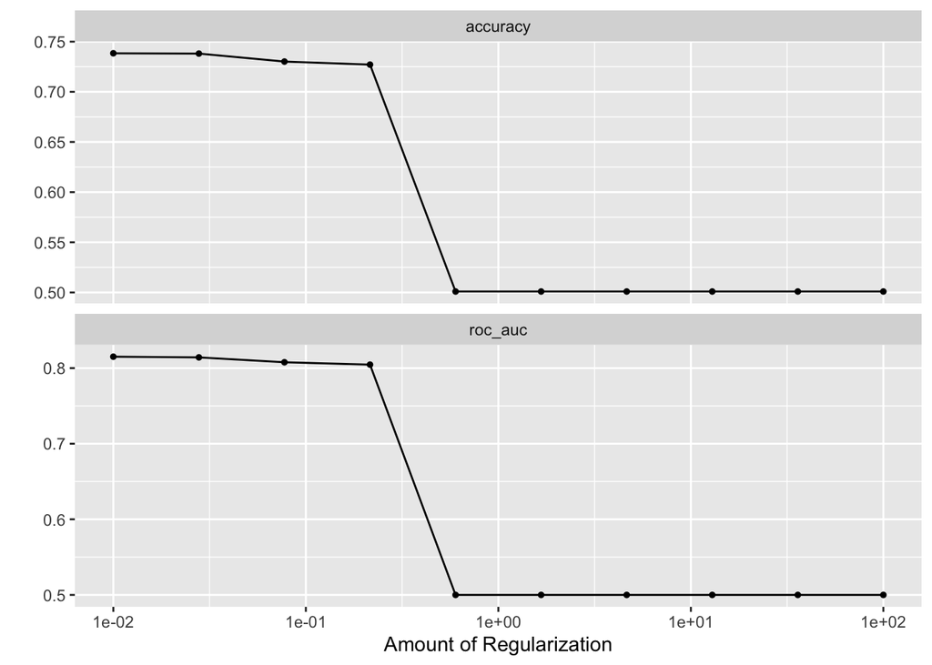

```r
# load model result
lasso_result <- read_rds("model_results/lasso_model.rds")
autoplot(lasso_result)
```

From the plot, the accuracy decrease sharply after a certain value of penalty.

```r
# show the best model
show_best(lasso_result, metric = "accuracy")
```

```
## # A tibble: 5 × 7
##   penalty .metric  .estimator  mean     n   std_err .config
##     <dbl> <chr>    <chr>      <dbl> <int>     <dbl> <chr>
## 1  0.01   accuracy binary     0.738     5 0.00151   Preprocessor1_Model01
## 2  0.0278 accuracy binary     0.738     5 0.00218   Preprocessor1_Model02
## 3  0.0774 accuracy binary     0.730     5 0.00108   Preprocessor1_Model03
## 4  0.215  accuracy binary     0.727     5 0.00187   Preprocessor1_Model04
## 5  0.599  accuracy binary     0.501     5 0.0000886 Preprocessor1_Model05
```

```r
# store the highest accuracy for this kind of model
lasso_acc <- show_best(lasso_result, metric = "accuracy") %>%
  filter(row_number()==1)
```

The highest accuracy given by lasso regression is about 0.7384 with `penalty = 0.01`.

#### Random Forest

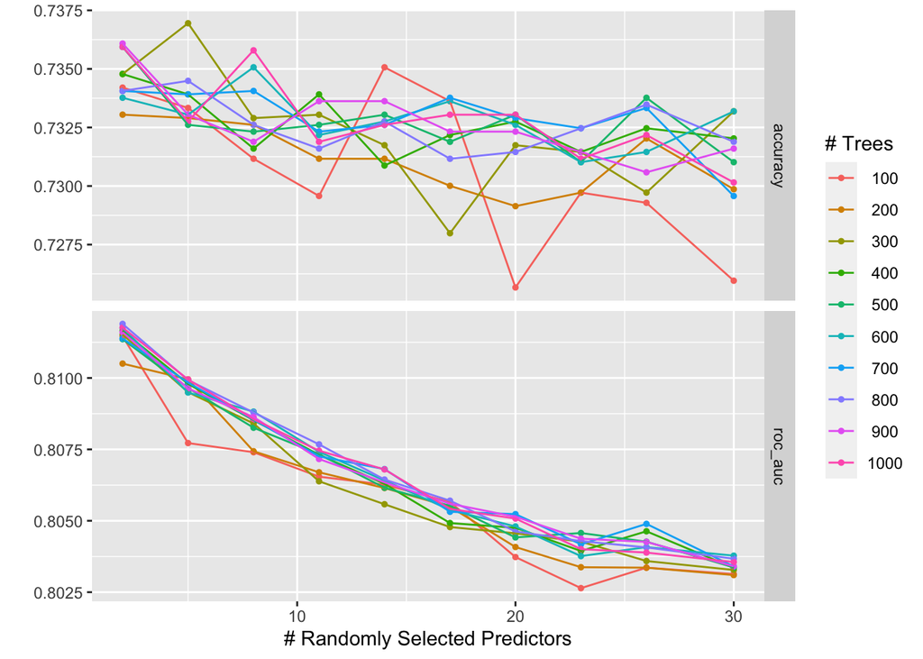

```r
# load model result
rf_result <- read_rds("model_results/random_forest_model.rds")
autoplot(rf_result)
```

```r
# show the best model
show_best(rf_result, metric = "accuracy")
```

```
## # A tibble: 5 × 8
##    mtry trees .metric  .estimator  mean     n std_err .config
##   <int> <int> <chr>    <chr>      <dbl> <int>   <dbl> <chr>
## 1     5   300 accuracy binary     0.737     5 0.00236 Preprocessor1_Model022
## 2     2   900 accuracy binary     0.736     5 0.00161 Preprocessor1_Model081
## 3     2  1000 accuracy binary     0.736     5 0.00196 Preprocessor1_Model091
## 4     2   500 accuracy binary     0.736     5 0.00211 Preprocessor1_Model041
## 5     8  1000 accuracy binary     0.736     5 0.00368 Preprocessor1_Model093
```

```r
# store the highest accuracy for this kind of model
rf_acc <- show_best(rf_result, metric = "accuracy") %>%
  filter(row_number()==1)
```

The highest accuracy given by random forest is about 0.7369 with `mtry = 5` and `trees = 300`.

#### Boosted Tree

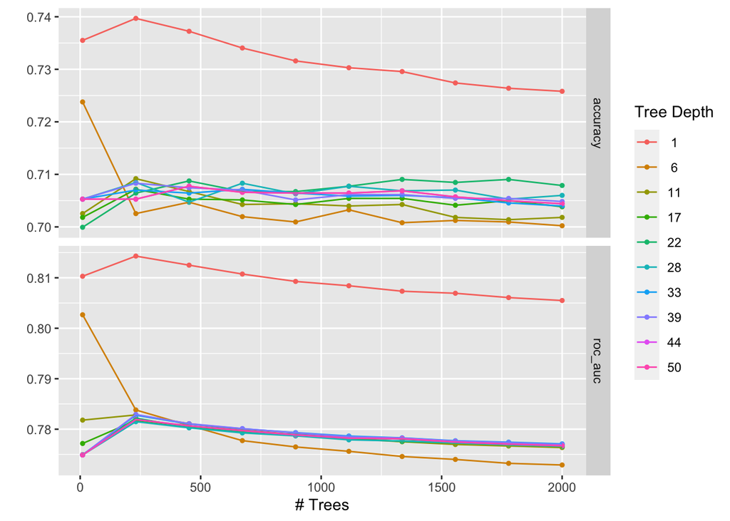

```r
# load model result
bt_result <- read_rds("model_results/boost_tree_model.rds")
autoplot(bt_result)
```

The model performs better when both the tree depth and the number of trees are smaller.

```r
# show the best model
show_best(bt_result, metric = "accuracy")
```

```
## # A tibble: 5 × 8
##   trees tree_depth .metric  .estimator  mean     n std_err .config
##   <int>      <int> <chr>    <chr>      <dbl> <int>   <dbl> <chr>
## 1   231          1 accuracy binary     0.740     5 0.00252 Preprocessor1_Model0…
## 2   452          1 accuracy binary     0.737     5 0.00220 Preprocessor1_Model0…
## 3    10          1 accuracy binary     0.736     5 0.00217 Preprocessor1_Model0…
## 4   673          1 accuracy binary     0.734     5 0.00265 Preprocessor1_Model0…
## 5   894          1 accuracy binary     0.732     5 0.00283 Preprocessor1_Model0…
```

```r
# store the highest accuracy for this kind of model
bt_acc <- show_best(bt_result, metric = "accuracy") %>%
  filter(row_number() == 1)
```

The highest accuracy given by boosted tree is about 0.7397 with `trees = 231` and `tree_depth = 1`.

#### Nearest Neighbor Model

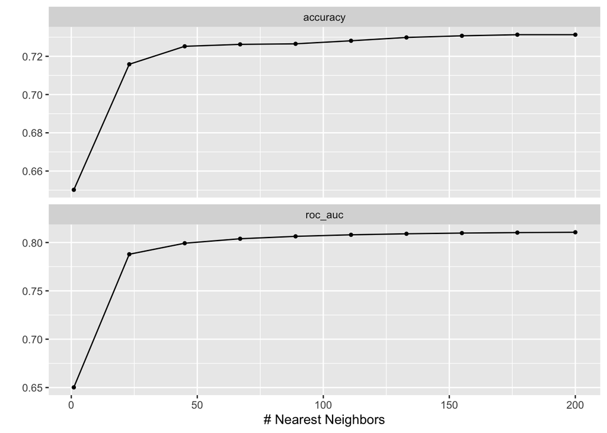

```r
# load model result
knn_result <- read_rds("model_results/knn_model.rds")
autoplot(knn_result)
```

The accuracy increases significantly when we increase the number of nearest neighbors to around 25, and then the accuracy doesn’t have any obvious movement as we continue to increase the number of nearest neighbors.

```r
# show the best model
show_best(knn_result, metric = "accuracy")
```

```
## # A tibble: 5 × 7
##   neighbors .metric  .estimator  mean     n std_err .config
##       <int> <chr>    <chr>      <dbl> <int>   <dbl> <chr>
## 1       200 accuracy binary     0.731     5 0.00199 Preprocessor1_Model10
## 2       177 accuracy binary     0.731     5 0.00253 Preprocessor1_Model09
## 3       155 accuracy binary     0.731     5 0.00204 Preprocessor1_Model08
## 4       133 accuracy binary     0.730     5 0.00244 Preprocessor1_Model07
## 5       111 accuracy binary     0.728     5 0.00275 Preprocessor1_Model06
```

```r
# store the highest accuracy for this kind of model
knn_acc <- show_best(knn_result, metric = "accuracy") %>%
  filter(row_number() == 1)
```

Synthesizing the accuracy for each kind of the model, we found that the boosted tree model gives the highest accuracy, so we will choose boosted tree as out best performance model.

```r
accuracy <- c(lasso_acc$mean,rf_acc$mean,bt_acc$mean,knn_acc$mean)
models <- c("Lasso Regression", "Random Forest", "Boosted Tree", "KNN")
results <- tibble(accuracy = accuracy, models =  models)
results %>%
  arrange(-accuracy)
```

```
## # A tibble: 4 × 2
##   accuracy models
##      <dbl> <chr>
## 1    0.740 Boosted Tree
## 2    0.738 Lasso Regression
## 3    0.737 Random Forest
## 4    0.731 KNN
```

### Final Model Fitting

Let’s fit the best boosted tree model on the entire training set:

```r
# select the best boosted tree model that give highest accuracy
best_model <- select_best(bt_result, metric = "accuracy")

# finalize the workflow by taking parameters from the best model
bt_final_wkflow <- finalize_workflow(boost_workflow, best_model)

# fit the model
bt_final_fit <- fit(bt_final_wkflow, data = rank_train)
```

### Analysis Performance on Test set

Let’s fit the final model on the test set and see the prediction accuracy:

```r
augment(bt_final_fit, new_data = rank_test) %>%
  accuracy(truth=winner, estimate =  .pred_class)
```

```
## # A tibble: 1 × 3
##   .metric  .estimator .estimate
##   <chr>    <chr>          <dbl>
## 1 accuracy binary         0.711
```

The model returned an accuracy of 0.7105 on the testing data, which is only slightly lower than the accuracy on training data.

Let’s see the confusion matrix:

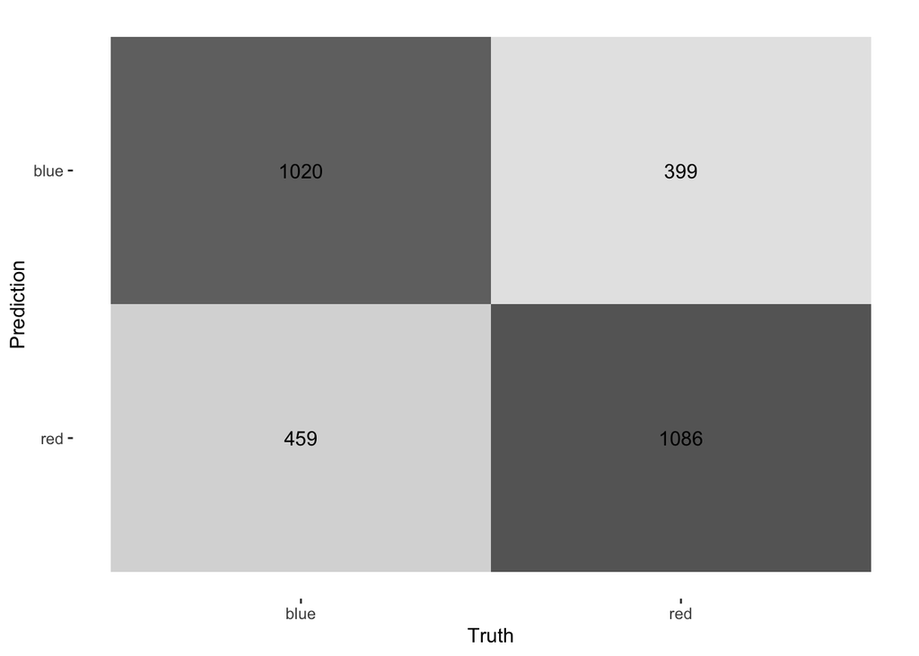

```r
augment(bt_final_fit, new_data = rank_test) %>%
  conf_mat(winner, .pred_class) %>%
  autoplot(type = "heatmap")
```

#### Check A Few Predictions

To examine the model accuracy in practice, I have randomly chosen some games and used the first ten mins’ statistics to see the model’s prediction result.

- Game 1

  This is a game randomly selected from the data set.

```r
game1 <- rank %>%
  filter(game_id == 4450484115) %>%
  select(-game_id)

predict(bt_final_fit, game1)
```

```
## # A tibble: 1 × 1
##   .pred_class
##   <fct>
## 1 blue
```

```r
rank %>%
  filter(game_id == 4450484115) %>%
  select(winner)
```

```
## # A tibble: 1 × 1
##   winner
##   <fct>
## 1 blue
```

```r
#correct
```

The model correctly predict the winner of this game.

- Game 2

  This is the game from the professional LoL competition, which is the first game of the Final of MSI 2022 between the team RNG and T1. RNG is the blue side, and T1 is the red side. I record the relevant data by myself when I watch the competition. I can not see each team’s total experiences from the game panel that was displayed when recording the match, so I calculated the mean total experiences from our data set that has the same average level.

```r
# approximate total_experience
rank %>%
  filter(blue_avg_level == 7) %>%
  summarise(mean(blue_total_experience))
```

```
## # A tibble: 1 × 1
##   `mean(blue_total_experience)`
##                           <dbl>
## 1                        18233.
```

```r
rank %>%
  filter(red_avg_level == 7.4) %>%
  summarise(mean(red_total_experience))
```

```
## # A tibble: 1 × 1
##   `mean(red_total_experience)`
##                          <dbl>
## 1                       19642.
```

```r
game2 <- data.frame(blue_kills = 2,
                    blue_deaths = 0,
                    blue_assists = 4,
                    blue_elite_monsters = 1,
                    blue_dragons = 0,
                    blue_heralds = 1,
                    blue_towers_destroyed = 0,
                    blue_total_gold = 15800,
                    blue_avg_level = 7,
                    blue_total_experience = 18233,
                    blue_total_minions_killed = 261,
                    blue_total_jungle_minions_killed = 67,
                    blue_gold_diff = -1000,
                    blue_experience_diff = -1409,
                    blue_cs_per_min = 26.1,
                    blue_gold_per_min = 1580,
                    red_kills = 0,
                    red_deaths = 2,
                    red_assists = 0,
                    red_elite_monsters = 0,
                    red_dragons = 0,
                    red_heralds = 0,
                    red_towers_destroyed = 0,
                    red_total_gold = 16800,
                    red_avg_level = 7.4,
                    red_total_experience = 19642,
                    red_total_minions_killed = 296,
                    red_total_jungle_minions_killed = 78,
                    red_gold_diff = 1000,
                    red_experience_diff = 1409,
                    red_cs_per_min = 29.6,
                    red_gold_per_min = 1680,
                    blue_kda = 2,
                    red_kda = 0,
                    blue_vision_score = 30,
                    red_vision_score = 25,
                    first_blood = "blue") %>%
  mutate(first_blood = factor(first_blood))

predict(bt_final_fit, game2)
```

```
## # A tibble: 1 × 1
##   .pred_class
##   <fct>
## 1 red
```

```r
#wrong
```

Our model didn’t correctly predict the winner this time. The blue side RNG wins this game instead.

- Game 3

  This is the second game of the Finals of MSI 2022 between the team RNG and T1. In this game, T1 is the blue side and the RNG is the red side. The data is recorded and approximated in the same way.

```r
# approximate total_experience
rank %>%
  filter(red_avg_level == 7.2) %>%
  summarise(mean(red_total_experience))
```

```
## # A tibble: 1 × 1
##   `mean(red_total_experience)`
##                          <dbl>
## 1                       18933.
```

```r
game3 <- data.frame(blue_kills = 3,
                    blue_deaths = 1,
                    blue_assists = 1,
                    blue_elite_monsters = 1,
                    blue_dragons = 0,
                    blue_heralds = 1,
                    blue_towers_destroyed = 0,
                    blue_total_gold = 16400,
                    blue_avg_level = 7,
                    blue_total_experience = 18233,
                    blue_total_minions_killed = 274,
                    blue_total_jungle_minions_killed = 61,
                    blue_gold_diff = 700,
                    blue_experience_diff = -700,
                    blue_cs_per_min = 27.4,
                    blue_gold_per_min = 1640,
                    red_kills = 1,
                    red_deaths = 3,
                    red_assists = 1,
                    red_elite_monsters = 1,
                    red_dragons = 1,
                    red_heralds = 0,
                    red_towers_destroyed = 0,
                    red_total_gold = 15700,
                    red_avg_level = 7.2,
                    red_total_experience = 18933,
                    red_total_minions_killed = 254,
                    red_total_jungle_minions_killed = 75,
                    red_gold_diff = -700,
                    red_experience_diff = 700,
                    red_cs_per_min = 25.4,
                    red_gold_per_min = 1570,
                    blue_kda = 4,
                    red_kda = 0.67,
                    blue_vision_score = 27,
                    red_vision_score = 35,
                    first_blood = "red") %>%
  mutate(first_blood = factor(first_blood))

predict(bt_final_fit, game3) #correct
```

```
## # A tibble: 1 × 1
##   .pred_class
##   <fct>
## 1 blue
```

Our model correctly predict the winner of this game. The Blue side T1 indeed wins this game.

- Game 4

  This is the fifth game of the Finals of MSI 2022 between the team RNG and T1. In this game, RNG is the blue side and the T1 is the red side. The data is recorded and approximated in the same way.

```r
# approximate total_experience
rank %>%
  filter(red_avg_level == 6.8) %>%
  summarise(mean(red_total_experience))
```

```
## # A tibble: 1 × 1
##   `mean(red_total_experience)`
##                          <dbl>
## 1                       17538.
```

```r
game4 <- data.frame(blue_kills = 4,
                    blue_deaths = 1,
                    blue_assists = 5,
                    blue_elite_monsters = 2,
                    blue_dragons = 1,
                    blue_heralds = 1,
                    blue_towers_destroyed = 0,
                    blue_total_gold = 16000,
                    blue_avg_level = 7,
                    blue_total_experience = 18233,
                    blue_total_minions_killed = 247,
                    blue_total_jungle_minions_killed = 57,
                    blue_gold_diff = 1500,
                    blue_experience_diff = 695,
                    blue_cs_per_min = 24.7,
                    blue_gold_per_min = 1600,
                    red_kills = 1,
                    red_deaths = 4,
                    red_assists = 1,
                    red_elite_monsters = 0,
                    red_dragons = 0,
                    red_heralds = 0,
                    red_towers_destroyed = 0,
                    red_total_gold = 14500,
                    red_avg_level = 6.8,
                    red_total_experience = 17538,
                    red_total_minions_killed = 246,
                    red_total_jungle_minions_killed = 60,
                    red_gold_diff = -1500,
                    red_experience_diff = -695,
                    red_cs_per_min = 24.6,
                    red_gold_per_min = 1450,
                    blue_kda = 9,
                    red_kda = 0.5,
                    blue_vision_score = 30,
                    red_vision_score = 29,
                    first_blood = "blue") %>%
  mutate(first_blood = factor(first_blood))

predict(bt_final_fit, game4) #correct
```

```
## # A tibble: 1 × 1
##   .pred_class
##   <fct>
## 1 blue
```

Our model also correctly predict the winner of this game.

## Conclusion

For all the model types, there are no significant differences in the accuracy of all the models. The boosted tree just has slightly higher accuracy than other models. The accuracy rate of just above 70% is just acceptable, but it has a higher potential to improve the prediction accuracy. From my point of view, our prediction accuracy is restricted by the limitation of data. Many other essential features could be incorporated into the analysis such as the champions that each player has chosen, interactions between champions, and game duration. Only the first ten minutes of players’ performances may also not be sufficient to accurately predict the winner of the game. Moreover, the model is trained using the solo rank data, the model built from such data might hard to generalize to predict the winner of professional LoL competitions because there are many differences between the normal rank game and professional competition. For example, we aren’t able to incorporate the player’s statistics into the model building process for solo rank data; whereas, we can incorporate the professional player’s historical performance into the model that tries to predict the winner of LoL matches. If we just focus on the game statistics itself, we found out that the playing habits are also very different for the professional competitions and normal rank games. Lastly, no matter in rank or E-sport competition, players can create many impossibilities in the world of the League of Legends, which are always unpredictable for building the model. This might be especially obvious as we build the model by only the first ten minutes of data. Overall, our model built on this rank data set to provide a rough example of how can we use game statistics to predict the winner of the game, which could be further refined to a more accurate model.